# Clinic Sales Analysis

## Background Overview

A fictional company called Einfach Medical Supplies (EMS) sells a disposable testing device that primary-care medical clinics. EMS believes they have the best product in the market and that doctors will buy if they can get the clinic to hear their pitch. Recently some of the sales force has suggested that it might be better to lead with a pitch other than the original one(focus on low cost). Therefore, the company decided to conduct an experiment, they took the clinics and randomized them into three groups: Control that received the original “cost-focused” pitch. Treatment 1 that received the “easier to use” pitch. Treatment 2 that received the “fewer errors” pitch.

## Columns Introduction

clinicnumber: The id of the clinic. These were randomly assigned and have no underlying meaning.

numdoctors: The number of doctors working at the clinic

avgpanelsize: An estimate of the average number of patients each of the doctors at this clinic has in their panel. These are patients who list the doctor as their primary care physician.

distance: The distance (in miles) between the clinic and the sales office assigned to pitch that clinic.

treatment: Takes value 0 for control, 1 for Treatment 1, 2 for Treatment 2

purchase: Takes a value of 0 if the clinic declined to purchase test kits from EMS and 1 if they did purchase test kits from EMS.

## Prepare Environment

Load the required packages and load the dataset.

```r
rm(list=ls())
data <- read.csv("clinicsales.csv")

library(knitr)
library(dplyr)
library(jtools)
library(rcompanion)
library(ggplot2)
library(car)
```

## Data Overview

Take a look at the first few rows of our data.

```r
head(data)
```

```
##   clinicnumber treatment purchase numdoctors avgpanelsize distance
## 1          108         2        1          6         2509        5
## 2          165         2        0          5         2340        7
## 3          205         1        0          4         2500        7
## 4          267         1        0          4         2073        8
## 5           36         2        0          4         2152        7
## 6           68         0        0          3         2415        8
```

Create a table of summary statistics for the variables in the data showing the min, max, mean and standard deviation of each variable.

```r
sumtb<- matrix(NA,nrow = 4, ncol = 6  )
rownames(sumtb) <- c("min","max","mean", "sd")
colnames(sumtb) <- colnames(data)
sumtb[1,] <- round(apply(data,2,min),2)
sumtb[2,] <- round(apply(data,2,max),2)
sumtb[3,] <- round(apply(data,2,mean),2)
sumtb[4,] <- round(apply(data,2,sd),2)
sumtb <- sumtb[,2:6]
kable(sumtb)
```

|  | treatment | purchase | numdoctors | avgpanelsize | distance |
| --- | --- | --- | --- | --- | --- |
| min | 0.00 | 0.00 | 1.00 | 2050.00 | 2.00 |
| max | 2.00 | 9.00 | 7.00 | 2546.00 | 437.00 |
| mean | 1.02 | 0.28 | 3.93 | 2303.75 | 35.31 |
| sd | 0.82 | 0.65 | 1.17 | 141.68 | 43.03 |

## Create a Table to Visualize the Shares in Each Group

Create a table of the shares of clinics in each of the experimental treat/control groups.

```r
attach(data)
tb_treatment<-matrix(NA, nrow = 2, ncol = 3)
tb_treatment[1,] <- round(table(treatment),0)
tb_treatment[2,] <- round(prop.table(table(treatment)),3)
rownames(tb_treatment) <- c("Frequency", "Proportion" )
colnames(tb_treatment) <- c("Control", "Treatment 1", "Treatment 2")
detach(data)
kable(tb_treatment)
```

|  | Control | Treatment 1 | Treatment 2 |
| --- | --- | --- | --- |
| Frequency | 106.000 | 105.000 | 111.000 |
| Proportion | 0.329 | 0.326 | 0.345 |

## Check for Balance on Pre-Treatment Variables

In order to ensure our experiment is precise, we check our pre-treatment variables to examine whether our control/experimental groups are similar.

## Compare Means

We first examine the means of all pre-treatment variables by different groups.

```r
attach(data)
preexp <-data %>%
  select(numdoctors,avgpanelsize,distance)
tb_preexp <- matrix(NA, nrow = 3, ncol = 3)
colnames(tb_preexp) <- c( "Control", "Treatment 1", "Treatment 2")
rownames(tb_preexp) <- colnames(preexp) #
m<-as.matrix(round(aggregate(.~treatment,preexp,mean),2))

tb_preexp[,1:3] <-t(m)[2:4,]
detach(data)
kable(tb_preexp)
```

|  | Control | Treatment 1 | Treatment 2 |
| --- | --- | --- | --- |
| numdoctors | 3.75 | 3.98 | 4.06 |
| avgpanelsize | 2291.79 | 2282.62 | 2335.16 |
| distance | 38.03 | 35.16 | 32.86 |

Seems like treatment group 1 is closer to control group in all variables. Treatment 2 group has a larger difference with control group. This is probably because we have a small sample size.

## Compare with Histograms

Besides comparing means, we also plot histograms to visualize the distribution of each pre-treatment variables.

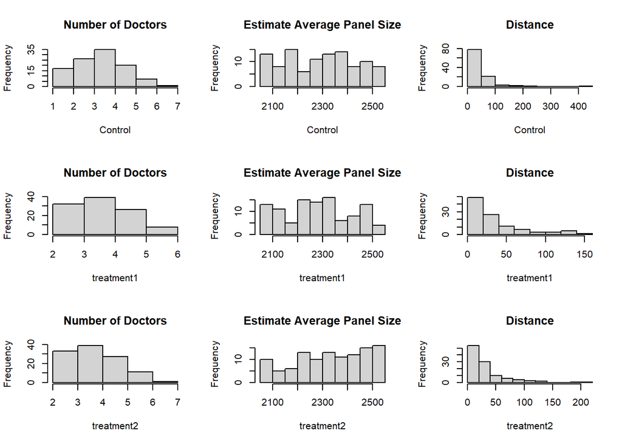

```r
attach(data)
par(mfrow=c(3,3))

hist(numdoctors[treatment==0], main = paste("Number of Doctors"), xlab = "Control")
hist(avgpanelsize[treatment==0], main = paste("Estimate Average Panel Size"), xlab = "Control")
hist(distance[treatment==0], main = paste("Distance"), xlab = "Control")

hist(numdoctors[treatment==1], main = paste("Number of Doctors"), xlab = "treatment1",breaks=5)
hist(avgpanelsize[treatment==1], main = paste("Estimate Average Panel Size"), xlab = "treatment1")
hist(distance[treatment==1], main = paste("Distance"), xlab = "treatment1")


hist(numdoctors[treatment==2], main = paste("Number of Doctors"), xlab = "treatment2",breaks =6)
hist(avgpanelsize[treatment==2], main = paste("Estimate Average Panel Size"), xlab = "treatment2")
hist(distance[treatment==2], main = paste("Distance"), xlab = "treatment2")
```

According to the plots, we could see that the distribution of the number of doctors and distance are similar.But the distribution of the estimate average panel size has a larger difference between treatment 2 and control group. While control group and treatment 1 group are more centralized, treatment 2 group’s frequency seems to increase as the panel size increase.

## Plot the Means and Confidence Intervals of “Purchase” by Control and Both Treatments Groups

First, I created a table including average number of purchase, error, and the confidence intervals.

```r
attach(data)
summary <- data %>%
  mutate(treatment = as.factor(treatment)) %>%
  group_by(treatment) %>%        #
  summarise(n = length(clinicnumber),
            avgnpurchase = round(mean(purchase),2),
            error = round(sd(purchase)/sqrt(n),3),
            lowerCI = round(avgnpurchase - 1.96*error,2),
            upperCI = round(avgnpurchase + 1.96*error,2))

kable(summary)
```

| treatment | n | avgnpurchase | error | lowerCI | upperCI |
| --- | --- | --- | --- | --- | --- |
| 0 | 106 | 0.12 | 0.032 | 0.06 | 0.18 |
| 1 | 105 | 0.33 | 0.046 | 0.24 | 0.42 |
| 2 | 111 | 0.37 | 0.090 | 0.19 | 0.55 |

Second, I visualized the table. we could see that both Treatment 1 and 2 has a higher mean of purchase, which indicates both the treatments have positive impact on purchase. Although treatment 2 has a higher sample mean than treatment 1, treatment 2 has a larger 95% confidence interval. We could also observe that treatment 2 ‘s error is almost twice as big as treatment 1’s error.

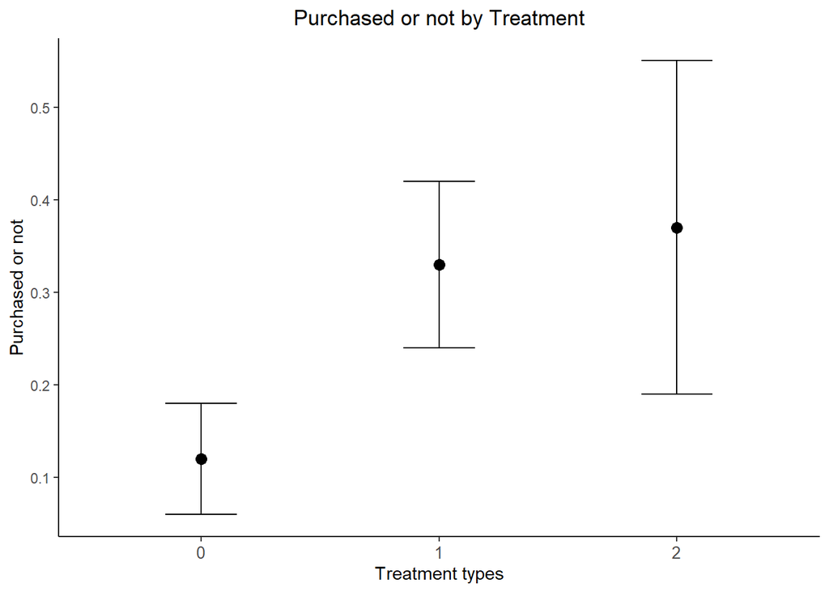

```r
summary %>%
  ggplot(aes(x=treatment)) +
  geom_point(aes(y = avgnpurchase), size = 3) +
  scale_shape_manual(values=c(15, 16)) +
  ggtitle("Purchased or not by Treatment") +
  ylab("Purchased or not") + xlab("Treatment types") +
  theme(panel.grid.major = element_blank(), panel.grid.minor = element_blank(),
        panel.background = element_blank(),axis.line = element_line(colour = "black"),
        axis.text.x= element_text(size = 10), legend.position=c(.5,.5),
        plot.title=element_text(hjust=.5))+
  geom_errorbar(aes(ymin = lowerCI,
                    ymax = upperCI), width = .3)+
  scale_color_manual(values=c("darkgrey","black"))
```

## Calculate ATE for Each Treatment

Calculate estimates of the Average Treatment Effect (ATE) of purchase for each treatment relative to control and provide a 95% confidence intervals on the Average Treatment Effects.

```r
ATE <-matrix(NA,ncol = 3, nrow = 3)
colnames(ATE) <- c("Treatment Effect units purchased", "Lower 95% CI", "Upper 95% CI" )
rownames(ATE) <- c("Treatment 1", "Treatment 2", "Control Mean")

effect <-c(summary$avgnpurchase[2]-summary$avgnpurchase[1],summary$avgnpurchase[3]-summary$avgnpurchase[1],summary$avgnpurchase[1])
error_rate <- c (sqrt(summary$error[1]^2+summary$error[2]^2),sqrt(summary$error[1]^2+summary$error[3]^2),NA )
LCI <- effect-1.96*error_rate
UCI <- effect+1.96*error_rate

ATE[,1] <-round(effect,3)
ATE[,2] <-round(LCI,3)
ATE[,3] <-round(UCI,3)

kable(ATE)
```

|  | Treatment Effect units purchased | Lower 95% CI | Upper 95% CI |
| --- | --- | --- | --- |
| Treatment 1 | 0.21 | 0.100 | 0.320 |
| Treatment 2 | 0.25 | 0.063 | 0.437 |
| Control Mean | 0.12 | NA | NA |

Above is the estimates of the Average Treatment Effect (ATE) of purchase for each treatment relative to control. We could observe similar results. Treatment 2 seems to have a higher average treatment effect, but it has a larger confidence interval.

## Conclusion

In conclusion, the pitch of “easier to use”, and the pitch of “fewer errors” seems to work better than “cost-focused “pitch. Clinics might care more about the performance of the product instead of the cost. Although “fewer errors” pitch looks more influential on purchase, but it is riskier to use “fewer errors” pitch because its 95% confidence interval is larger. We might want to increase our sample size or reduce the variation to narrow down its confidence interval before we decide which treatment to adopt.

## Recommendation

There are one additional outcome metrics I would ideally like to examine as part of the analysis of this experiment. It is the number of nurses. Since the sales people might be invited to give a full pitch of the product to the doctors and nurse practitioners in the clinic, I think only include the number of doctors might be insufficient. Maybe the people who are actually using our products are nurses.

## Caveats and Limitations

1.I observed that the outcomes of purchase should be either 0 or 1, but there is a value 9 in the purchase variable.

2.I also observed that the distribution of variable “avgpanelsize” is not similar among control group and both treatment groups. We might want to increase our sample size, otherwise, our results might be biased.